# Risk Factor Analysis

## Outcome Variable

**Outcome Variable:** haz

## Predictor Variables

**Intervention Variable:** safeh20

**Adjustment Set:**

- arm
- sex
- W_mage
- meducyrs
- feducyrs
- hhwealth_quart
- hfoodsec
- W_mhtcm
- W_mwtkg
- W_mbmi
- W_nrooms
- W_nchldlt5
- W_parity
- impfloor
- impsan
- delta_W_mage
- delta_meducyrs
- delta_feducyrs
- delta_hhwealth_quart
- delta_hfoodsec
- delta_W_mhtcm
- delta_W_mwtkg
- delta_W_mbmi
- delta_W_nrooms
- delta_W_nchldlt5
- delta_W_parity
- delta_impfloor
- delta_impsan

## Stratifying Variables

The analysis was stratified on these variable(s):

- agecat
- studyid
- country

## Data Summary

| agecat | studyid | country | safeh20 | n_cell | n |
| --- | --- | --- | --- | --- | --- |
| Birth | ki0047075b-MAL-ED | BANGLADESH | 1 | 0 | 213 |
| Birth | ki0047075b-MAL-ED | BANGLADESH | 0 | 213 | 213 |
| Birth | ki0047075b-MAL-ED | BRAZIL | 1 | 0 | 41 |
| Birth | ki0047075b-MAL-ED | BRAZIL | 0 | 41 | 41 |
| Birth | ki0047075b-MAL-ED | INDIA | 1 | 0 | 41 |
| Birth | ki0047075b-MAL-ED | INDIA | 0 | 41 | 41 |
| Birth | ki0047075b-MAL-ED | NEPAL | 1 | 1 | 26 |
| Birth | ki0047075b-MAL-ED | NEPAL | 0 | 25 | 26 |
| Birth | ki0047075b-MAL-ED | PERU | 1 | 9 | 207 |
| Birth | ki0047075b-MAL-ED | PERU | 0 | 198 | 207 |
| Birth | ki0047075b-MAL-ED | SOUTH AFRICA | 1 | 13 | 96 |
| Birth | ki0047075b-MAL-ED | SOUTH AFRICA | 0 | 83 | 96 |
| Birth | ki0047075b-MAL-ED | TANZANIA, UNITED REPUBLIC OF | 1 | 79 | 119 |
| Birth | ki0047075b-MAL-ED | TANZANIA, UNITED REPUBLIC OF | 0 | 40 | 119 |
| Birth | ki1017093-NIH-Birth | BANGLADESH | 1 | 606 | 608 |
| Birth | ki1017093-NIH-Birth | BANGLADESH | 0 | 2 | 608 |
| Birth | ki1017093b-PROVIDE | BANGLADESH | 1 | 45 | 45 |
| Birth | ki1017093b-PROVIDE | BANGLADESH | 0 | 0 | 45 |
| Birth | ki1017093c-NIH-Crypto | BANGLADESH | 1 | 732 | 732 |
| Birth | ki1017093c-NIH-Crypto | BANGLADESH | 0 | 0 | 732 |
| Birth | kiGH5241-JiVitA-3 | BANGLADESH | 1 | 26599 | 26642 |
| Birth | kiGH5241-JiVitA-3 | BANGLADESH | 0 | 43 | 26642 |
| Birth | kiGH5241-JiVitA-4 | BANGLADESH | 1 | 2820 | 2820 |
| Birth | kiGH5241-JiVitA-4 | BANGLADESH | 0 | 0 | 2820 |
| 6 months | ki0047075b-MAL-ED | BANGLADESH | 1 | 0 | 240 |
| 6 months | ki0047075b-MAL-ED | BANGLADESH | 0 | 240 | 240 |
| 6 months | ki0047075b-MAL-ED | BRAZIL | 1 | 0 | 142 |
| 6 months | ki0047075b-MAL-ED | BRAZIL | 0 | 142 | 142 |
| 6 months | ki0047075b-MAL-ED | INDIA | 1 | 0 | 235 |
| 6 months | ki0047075b-MAL-ED | INDIA | 0 | 235 | 235 |

[output cut: 52 more lines]

The following strata were considered:

- agecat: 24 months, studyid: ki0047075b-MAL-ED, country: BANGLADESH
- agecat: 24 months, studyid: ki0047075b-MAL-ED, country: BRAZIL
- agecat: 24 months, studyid: ki0047075b-MAL-ED, country: INDIA
- agecat: 24 months, studyid: ki0047075b-MAL-ED, country: NEPAL
- agecat: 24 months, studyid: ki0047075b-MAL-ED, country: PERU
- agecat: 24 months, studyid: ki0047075b-MAL-ED, country: SOUTH AFRICA
- agecat: 24 months, studyid: ki0047075b-MAL-ED, country: TANZANIA, UNITED REPUBLIC OF
- agecat: 24 months, studyid: ki1017093-NIH-Birth, country: BANGLADESH
- agecat: 24 months, studyid: ki1017093b-PROVIDE, country: BANGLADESH
- agecat: 24 months, studyid: ki1017093c-NIH-Crypto, country: BANGLADESH
- agecat: 24 months, studyid: ki1114097-CONTENT, country: PERU
- agecat: 24 months, studyid: ki1148112-LCNI-5, country: MALAWI
- agecat: 24 months, studyid: kiGH5241-JiVitA-3, country: BANGLADESH
- agecat: 24 months, studyid: kiGH5241-JiVitA-4, country: BANGLADESH
- agecat: 6 months, studyid: ki0047075b-MAL-ED, country: BANGLADESH
- agecat: 6 months, studyid: ki0047075b-MAL-ED, country: BRAZIL
- agecat: 6 months, studyid: ki0047075b-MAL-ED, country: INDIA
- agecat: 6 months, studyid: ki0047075b-MAL-ED, country: NEPAL
- agecat: 6 months, studyid: ki0047075b-MAL-ED, country: PERU
- agecat: 6 months, studyid: ki0047075b-MAL-ED, country: SOUTH AFRICA
- agecat: 6 months, studyid: ki0047075b-MAL-ED, country: TANZANIA, UNITED REPUBLIC OF
- agecat: 6 months, studyid: ki1000304b-SAS-FoodSuppl, country: INDIA
- agecat: 6 months, studyid: ki1017093-NIH-Birth, country: BANGLADESH
- agecat: 6 months, studyid: ki1017093b-PROVIDE, country: BANGLADESH
- agecat: 6 months, studyid: ki1017093c-NIH-Crypto, country: BANGLADESH
- agecat: 6 months, studyid: ki1114097-CONTENT, country: PERU
- agecat: 6 months, studyid: ki1148112-LCNI-5, country: MALAWI
- agecat: 6 months, studyid: kiGH5241-JiVitA-3, country: BANGLADESH
- agecat: 6 months, studyid: kiGH5241-JiVitA-4, country: BANGLADESH
- agecat: Birth, studyid: ki0047075b-MAL-ED, country: BANGLADESH
- agecat: Birth, studyid: ki0047075b-MAL-ED, country: BRAZIL
- agecat: Birth, studyid: ki0047075b-MAL-ED, country: INDIA
- agecat: Birth, studyid: ki0047075b-MAL-ED, country: NEPAL
- agecat: Birth, studyid: ki0047075b-MAL-ED, country: PERU
- agecat: Birth, studyid: ki0047075b-MAL-ED, country: SOUTH AFRICA
- agecat: Birth, studyid: ki0047075b-MAL-ED, country: TANZANIA, UNITED REPUBLIC OF
- agecat: Birth, studyid: ki1017093-NIH-Birth, country: BANGLADESH
- agecat: Birth, studyid: ki1017093b-PROVIDE, country: BANGLADESH
- agecat: Birth, studyid: ki1017093c-NIH-Crypto, country: BANGLADESH
- agecat: Birth, studyid: kiGH5241-JiVitA-3, country: BANGLADESH
- agecat: Birth, studyid: kiGH5241-JiVitA-4, country: BANGLADESH

### Dropped Strata

- agecat: Birth, studyid: ki0047075b-MAL-ED, country: BANGLADESH
- agecat: Birth, studyid: ki0047075b-MAL-ED, country: BRAZIL
- agecat: Birth, studyid: ki0047075b-MAL-ED, country: INDIA
- agecat: Birth, studyid: ki0047075b-MAL-ED, country: NEPAL
- agecat: Birth, studyid: ki1017093-NIH-Birth, country: BANGLADESH
- agecat: Birth, studyid: ki1017093b-PROVIDE, country: BANGLADESH
- agecat: Birth, studyid: ki1017093c-NIH-Crypto, country: BANGLADESH
- agecat: Birth, studyid: kiGH5241-JiVitA-4, country: BANGLADESH
- agecat: 6 months, studyid: ki0047075b-MAL-ED, country: BANGLADESH
- agecat: 6 months, studyid: ki0047075b-MAL-ED, country: BRAZIL
- agecat: 6 months, studyid: ki0047075b-MAL-ED, country: INDIA
- agecat: 6 months, studyid: ki0047075b-MAL-ED, country: NEPAL
- agecat: 6 months, studyid: ki1000304b-SAS-FoodSuppl, country: INDIA
- agecat: 6 months, studyid: ki1017093-NIH-Birth, country: BANGLADESH
- agecat: 6 months, studyid: ki1017093b-PROVIDE, country: BANGLADESH
- agecat: 6 months, studyid: ki1017093c-NIH-Crypto, country: BANGLADESH
- agecat: 6 months, studyid: ki1114097-CONTENT, country: PERU
- agecat: 6 months, studyid: kiGH5241-JiVitA-4, country: BANGLADESH
- agecat: 24 months, studyid: ki0047075b-MAL-ED, country: BANGLADESH
- agecat: 24 months, studyid: ki0047075b-MAL-ED, country: BRAZIL
- agecat: 24 months, studyid: ki0047075b-MAL-ED, country: INDIA
- agecat: 24 months, studyid: ki0047075b-MAL-ED, country: NEPAL
- agecat: 24 months, studyid: ki1017093-NIH-Birth, country: BANGLADESH
- agecat: 24 months, studyid: ki1017093b-PROVIDE, country: BANGLADESH
- agecat: 24 months, studyid: ki1017093c-NIH-Crypto, country: BANGLADESH
- agecat: 24 months, studyid: ki1114097-CONTENT, country: PERU
- agecat: 24 months, studyid: kiGH5241-JiVitA-4, country: BANGLADESH

## Methods Detail

We’re interested in the causal parameters $E[Y_a]$ for all values of $a \in \mathcal{A}$. These parameters represent the mean outcome if, possibly contrary to fact, we intervened to set all units to have $A=a$. Under the randomization and positivity assumptions, these are identified by the statistical parameters $\psi_a=E_W[E_{Y|A,W}(Y|A=a,W)]$. In addition, we’re interested in the mean of $Y$, $E[Y]$ under no intervention (the observed mean). We will estimate these parameters by using SuperLearner to fit the relevant likelihood factors – $E_{Y|A,W}(Y|A=a,W)$ and $p(A=a|W)$, and then updating our likelihood fit using a joint TMLE.

For unadjusted analyses ($W=\{\}$), initial likelihoods were estimated using Lrnr_glm to estimate the simple $E(Y|A)$ and Lrnr_mean to estimate $p(A)$. For adjusted analyses, a small library containing Lrnr_glmnet, Lrnr_xgboost, and Lrnr_mean was used.

Having estimated these parameters, we will then use the delta method to estimate relative risks and attributable risks relative to a prespecified baseline level of $A$.

# Results Detail

## Results Plots

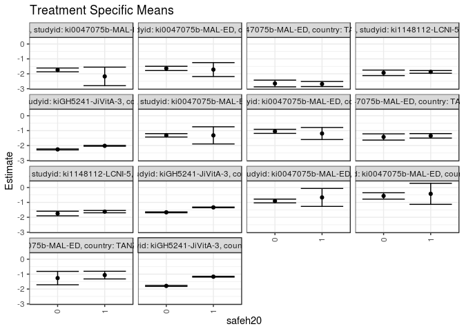

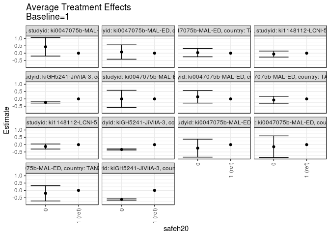

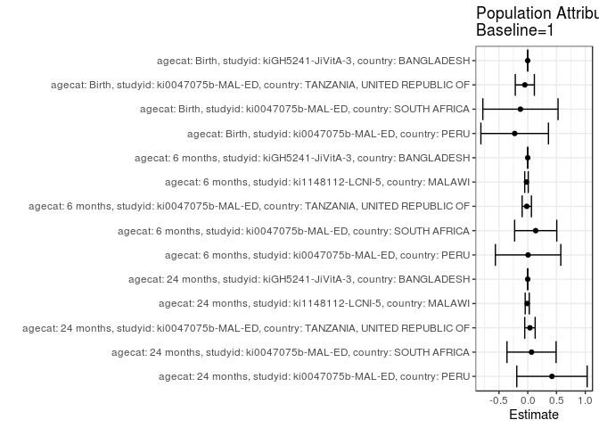

## Results Table

### Parameter: TSM

| agecat | studyid | country | intervention_level | baseline_level | estimate | ci_lower | ci_upper |
| --- | --- | --- | --- | --- | --- | --- | --- |
| Birth | ki0047075b-MAL-ED | PERU | 1 | NA | -0.6677778 | -1.2689426 | -0.0666129 |
| Birth | ki0047075b-MAL-ED | PERU | 0 | NA | -0.9054040 | -1.0308665 | -0.7799416 |
| Birth | ki0047075b-MAL-ED | SOUTH AFRICA | 1 | NA | -0.4251897 | -1.1320596 | 0.2816802 |
| Birth | ki0047075b-MAL-ED | SOUTH AFRICA | 0 | NA | -0.5671133 | -0.7817031 | -0.3525234 |
| Birth | ki0047075b-MAL-ED | TANZANIA, UNITED REPUBLIC OF | 1 | NA | -1.0650263 | -1.3221816 | -0.8078710 |
| Birth | ki0047075b-MAL-ED | TANZANIA, UNITED REPUBLIC OF | 0 | NA | -1.2648522 | -1.7147377 | -0.8149668 |
| Birth | kiGH5241-JiVitA-3 | BANGLADESH | 1 | NA | -1.1719515 | -1.2006434 | -1.1432596 |
| Birth | kiGH5241-JiVitA-3 | BANGLADESH | 0 | NA | -1.7911379 | -1.8256596 | -1.7566162 |
| 6 months | ki0047075b-MAL-ED | PERU | 1 | NA | -1.3177104 | -1.8937621 | -0.7416586 |
| 6 months | ki0047075b-MAL-ED | PERU | 0 | NA | -1.3147681 | -1.4279556 | -1.2015807 |
| 6 months | ki0047075b-MAL-ED | SOUTH AFRICA | 1 | NA | -1.1921385 | -1.5979437 | -0.7863332 |
| 6 months | ki0047075b-MAL-ED | SOUTH AFRICA | 0 | NA | -1.0480475 | -1.1844559 | -0.9116390 |
| 6 months | ki0047075b-MAL-ED | TANZANIA, UNITED REPUBLIC OF | 1 | NA | -1.3490604 | -1.4993016 | -1.1988193 |
| 6 months | ki0047075b-MAL-ED | TANZANIA, UNITED REPUBLIC OF | 0 | NA | -1.4244825 | -1.6338182 | -1.2151468 |
| 6 months | ki1148112-LCNI-5 | MALAWI | 1 | NA | -1.6206825 | -1.6974656 | -1.5438994 |
| 6 months | ki1148112-LCNI-5 | MALAWI | 0 | NA | -1.7473630 | -1.9034316 | -1.5912944 |
| 6 months | kiGH5241-JiVitA-3 | BANGLADESH | 1 | NA | -1.3353364 | -1.3589387 | -1.3117341 |
| 6 months | kiGH5241-JiVitA-3 | BANGLADESH | 0 | NA | -1.6667688 | -1.6967370 | -1.6368006 |
| 24 months | ki0047075b-MAL-ED | PERU | 1 | NA | -2.1757143 | -2.7976265 | -1.5538020 |
| 24 months | ki0047075b-MAL-ED | PERU | 0 | NA | -1.7386828 | -1.8660283 | -1.6113373 |
| 24 months | ki0047075b-MAL-ED | SOUTH AFRICA | 1 | NA | -1.7170638 | -2.1848328 | -1.2492947 |
| 24 months | ki0047075b-MAL-ED | SOUTH AFRICA | 0 | NA | -1.6390751 | -1.7817791 | -1.4963710 |
| 24 months | ki0047075b-MAL-ED | TANZANIA, UNITED REPUBLIC OF | 1 | NA | -2.6865447 | -2.8568364 | -2.5162530 |
| 24 months | ki0047075b-MAL-ED | TANZANIA, UNITED REPUBLIC OF | 0 | NA | -2.6503957 | -2.8756900 | -2.4251014 |
| 24 months | ki1148112-LCNI-5 | MALAWI | 1 | NA | -1.8732933 | -1.9639503 | -1.7826364 |
| 24 months | ki1148112-LCNI-5 | MALAWI | 0 | NA | -1.9348729 | -2.1195461 | -1.7501996 |
| 24 months | kiGH5241-JiVitA-3 | BANGLADESH | 1 | NA | -2.0192230 | -2.0475133 | -1.9909326 |
| 24 months | kiGH5241-JiVitA-3 | BANGLADESH | 0 | NA | -2.2601466 | -2.2935738 | -2.2267193 |

### Parameter: E(Y)

| agecat | studyid | country | intervention_level | baseline_level | estimate | ci_lower | ci_upper |
| --- | --- | --- | --- | --- | --- | --- | --- |
| Birth | ki0047075b-MAL-ED | PERU | NA | NA | -0.8950725 | -1.0180716 | -0.7720734 |
| Birth | ki0047075b-MAL-ED | SOUTH AFRICA | NA | NA | -0.5523958 | -0.7550074 | -0.3497843 |
| Birth | ki0047075b-MAL-ED | TANZANIA, UNITED REPUBLIC OF | NA | NA | -1.1158824 | -1.3283278 | -0.9034369 |
| Birth | kiGH5241-JiVitA-3 | BANGLADESH | NA | NA | -1.1729536 | -1.2010222 | -1.1448850 |
| 6 months | ki0047075b-MAL-ED | PERU | NA | NA | -1.3116216 | -1.4217664 | -1.2014769 |
| 6 months | ki0047075b-MAL-ED | SOUTH AFRICA | NA | NA | -1.0539919 | -1.1841437 | -0.9238401 |
| 6 months | ki0047075b-MAL-ED | TANZANIA, UNITED REPUBLIC OF | NA | NA | -1.3658943 | -1.4882808 | -1.2435078 |
| 6 months | ki1148112-LCNI-5 | MALAWI | NA | NA | -1.6426961 | -1.7120603 | -1.5733318 |
| 6 months | kiGH5241-JiVitA-3 | BANGLADESH | NA | NA | -1.3357056 | -1.3587889 | -1.3126223 |
| 24 months | ki0047075b-MAL-ED | PERU | NA | NA | -1.7545337 | -1.8798502 | -1.6292172 |
| 24 months | ki0047075b-MAL-ED | SOUTH AFRICA | NA | NA | -1.6512658 | -1.7868828 | -1.5156488 |
| 24 months | ki0047075b-MAL-ED | TANZANIA, UNITED REPUBLIC OF | NA | NA | -2.6484507 | -2.7840006 | -2.5129008 |
| 24 months | ki1148112-LCNI-5 | MALAWI | NA | NA | -1.8822648 | -1.9637218 | -1.8008078 |
| 24 months | kiGH5241-JiVitA-3 | BANGLADESH | NA | NA | -2.0194951 | -2.0471365 | -1.9918537 |

### Parameter: ATE

| agecat | studyid | country | intervention_level | baseline_level | estimate | ci_lower | ci_upper |
| --- | --- | --- | --- | --- | --- | --- | --- |
| Birth | ki0047075b-MAL-ED | PERU | 1 | 1 | 0.0000000 | 0.0000000 | 0.0000000 |
| Birth | ki0047075b-MAL-ED | PERU | 0 | 1 | -0.2376263 | -0.8517435 | 0.3764910 |
| Birth | ki0047075b-MAL-ED | SOUTH AFRICA | 1 | 1 | 0.0000000 | 0.0000000 | 0.0000000 |
| Birth | ki0047075b-MAL-ED | SOUTH AFRICA | 0 | 1 | -0.1419236 | -0.8827977 | 0.5989505 |
| Birth | ki0047075b-MAL-ED | TANZANIA, UNITED REPUBLIC OF | 1 | 1 | 0.0000000 | 0.0000000 | 0.0000000 |
| Birth | ki0047075b-MAL-ED | TANZANIA, UNITED REPUBLIC OF | 0 | 1 | -0.1998259 | -0.7192658 | 0.3196140 |
| Birth | kiGH5241-JiVitA-3 | BANGLADESH | 1 | 1 | 0.0000000 | 0.0000000 | 0.0000000 |
| Birth | kiGH5241-JiVitA-3 | BANGLADESH | 0 | 1 | -0.6191864 | -0.6626942 | -0.5756785 |
| 6 months | ki0047075b-MAL-ED | PERU | 1 | 1 | 0.0000000 | 0.0000000 | 0.0000000 |
| 6 months | ki0047075b-MAL-ED | PERU | 0 | 1 | 0.0029423 | -0.5845853 | 0.5904698 |
| 6 months | ki0047075b-MAL-ED | SOUTH AFRICA | 1 | 1 | 0.0000000 | 0.0000000 | 0.0000000 |
| 6 months | ki0047075b-MAL-ED | SOUTH AFRICA | 0 | 1 | 0.1440910 | -0.2843288 | 0.5725109 |
| 6 months | ki0047075b-MAL-ED | TANZANIA, UNITED REPUBLIC OF | 1 | 1 | 0.0000000 | 0.0000000 | 0.0000000 |
| 6 months | ki0047075b-MAL-ED | TANZANIA, UNITED REPUBLIC OF | 0 | 1 | -0.0754221 | -0.3325210 | 0.1816768 |
| 6 months | ki1148112-LCNI-5 | MALAWI | 1 | 1 | 0.0000000 | 0.0000000 | 0.0000000 |
| 6 months | ki1148112-LCNI-5 | MALAWI | 0 | 1 | -0.1266805 | -0.2996432 | 0.0462821 |
| 6 months | kiGH5241-JiVitA-3 | BANGLADESH | 1 | 1 | 0.0000000 | 0.0000000 | 0.0000000 |
| 6 months | kiGH5241-JiVitA-3 | BANGLADESH | 0 | 1 | -0.3314324 | -0.3681043 | -0.2947605 |
| 24 months | ki0047075b-MAL-ED | PERU | 1 | 1 | 0.0000000 | 0.0000000 | 0.0000000 |
| 24 months | ki0047075b-MAL-ED | PERU | 0 | 1 | 0.4370315 | -0.1977848 | 1.0718478 |
| 24 months | ki0047075b-MAL-ED | SOUTH AFRICA | 1 | 1 | 0.0000000 | 0.0000000 | 0.0000000 |
| 24 months | ki0047075b-MAL-ED | SOUTH AFRICA | 0 | 1 | 0.0779887 | -0.4111061 | 0.5670834 |
| 24 months | ki0047075b-MAL-ED | TANZANIA, UNITED REPUBLIC OF | 1 | 1 | 0.0000000 | 0.0000000 | 0.0000000 |
| 24 months | ki0047075b-MAL-ED | TANZANIA, UNITED REPUBLIC OF | 0 | 1 | 0.0361490 | -0.2477379 | 0.3200358 |
| 24 months | ki1148112-LCNI-5 | MALAWI | 1 | 1 | 0.0000000 | 0.0000000 | 0.0000000 |
| 24 months | ki1148112-LCNI-5 | MALAWI | 0 | 1 | -0.0615795 | -0.2675214 | 0.1443624 |
| 24 months | kiGH5241-JiVitA-3 | BANGLADESH | 1 | 1 | 0.0000000 | 0.0000000 | 0.0000000 |
| 24 months | kiGH5241-JiVitA-3 | BANGLADESH | 0 | 1 | -0.2409236 | -0.2837860 | -0.1980612 |

### Parameter: PAR

| agecat | studyid | country | intervention_level | baseline_level | estimate | ci_lower | ci_upper |
| --- | --- | --- | --- | --- | --- | --- | --- |
| Birth | ki0047075b-MAL-ED | PERU | 1 | NA | -0.2272947 | -0.8147485 | 0.3601591 |
| Birth | ki0047075b-MAL-ED | SOUTH AFRICA | 1 | NA | -0.1272061 | -0.7812044 | 0.5267922 |
| Birth | ki0047075b-MAL-ED | TANZANIA, UNITED REPUBLIC OF | 1 | NA | -0.0508560 | -0.2167217 | 0.1150096 |
| Birth | kiGH5241-JiVitA-3 | BANGLADESH | 1 | NA | -0.0010021 | -0.0021606 | 0.0001565 |
| 6 months | ki0047075b-MAL-ED | PERU | 1 | NA | 0.0060888 | -0.5625689 | 0.5747464 |
| 6 months | ki0047075b-MAL-ED | SOUTH AFRICA | 1 | NA | 0.1381466 | -0.2281755 | 0.5044686 |
| 6 months | ki0047075b-MAL-ED | TANZANIA, UNITED REPUBLIC OF | 1 | NA | -0.0168339 | -0.0975586 | 0.0638909 |
| 6 months | ki1148112-LCNI-5 | MALAWI | 1 | NA | -0.0220136 | -0.0526454 | 0.0086182 |
| 6 months | kiGH5241-JiVitA-3 | BANGLADESH | 1 | NA | -0.0003692 | -0.0012714 | 0.0005330 |
| 24 months | ki0047075b-MAL-ED | PERU | 1 | NA | 0.4211806 | -0.1907204 | 1.0330816 |
| 24 months | ki0047075b-MAL-ED | SOUTH AFRICA | 1 | NA | 0.0657979 | -0.3612099 | 0.4928057 |
| 24 months | ki0047075b-MAL-ED | TANZANIA, UNITED REPUBLIC OF | 1 | NA | 0.0380940 | -0.0525557 | 0.1287436 |
| 24 months | ki1148112-LCNI-5 | MALAWI | 1 | NA | -0.0089715 | -0.0444136 | 0.0264706 |
| 24 months | kiGH5241-JiVitA-3 | BANGLADESH | 1 | NA | -0.0002721 | -0.0014188 | 0.0008745 |